# Red Wine Physicochemical Properties and Quality by Oliver Koch

## Introduction to the Dataset

The dataset is related to red variants of the Portuguese “Vinho Verde” wine. It contains physical and chemical properties from objective measurements and a sensory assessment of the quality of the wine (median of at least 3 evaluations made by wine experts).

The dataset is available at this URL: https://s3.amazonaws.com/udacity-hosted-downloads/ud651/wineQualityReds.csv

The details are described in *P. Cortez, A. Cerdeira, F. Almeida, T. Matos and J. Reis. Modeling wine preferences by data mining from physicochemical properties. In Decision Support Systems, Elsevier, 47(4):547-553. ISSN: 0167-9236*, available at http://www3.dsi.uminho.pt/pcortez/wine5.pdf

### Attribute information:

Input variables (based on physicochemical tests):

1. Fixed acidity (tartaric acid - g / dm^3): most acids involved with wine or fixed or nonvolatile (do not evaporate readily)
2. Volatile acidity (acetic acid - g / dm^3): the amount of acetic acid in wine, which at too high of levels can lead to an unpleasant, vinegar taste
3. Citric acid (g / dm^3): found in small quantities, citric acid can add ‘freshness’ and flavor to wines
4. Residual sugar (g / dm^3): the amount of sugar remaining after fermentation stops, it’s rare to find wines with less than 1 gram/liter and wines with greater than 45 grams/liter are considered sweet
5. Chlorides (sodium chloride - g / dm^3): the amount of salt in the wine
6. Free sulfur dioxide (mg / dm^3): the free form of SO2 exists in equilibrium between molecular SO2 (as a dissolved gas) and bisulfite ion; it prevents microbial growth and the oxidation of wine
7. Total sulfur dioxide (mg / dm^3): amount of free and bound forms of S02; in low concentrations, SO2 is mostly undetectable in wine, but at free SO2 concentrations over 50 ppm, SO2 becomes evident in the nose and taste of wine
8. Density (g / cm^3): the density of water is close to that of water depending on the percent alcohol and sugar content
9. pH: describes how acidic or basic a wine is on a scale from 0 (very acidic) to 14 (very basic); most wines are between 3-4 on the pH scale
10. Sulphates (potassium sulphate - g / dm3): sulphates: a wine additive which can contribute to sulfur dioxide gas (S02) levels, wich acts as an antimicrobial and antioxidant
11. Alcohol (% by volume): the percent alcohol content of the wine

Output variable (based on sensory data):

12. Quality. Score between 0 (very bad) and 10 (very good)

# Univariate Plots Section

An array of histograms and an array of boxplots provide a first overview of the ranges of values and the distribution of data:

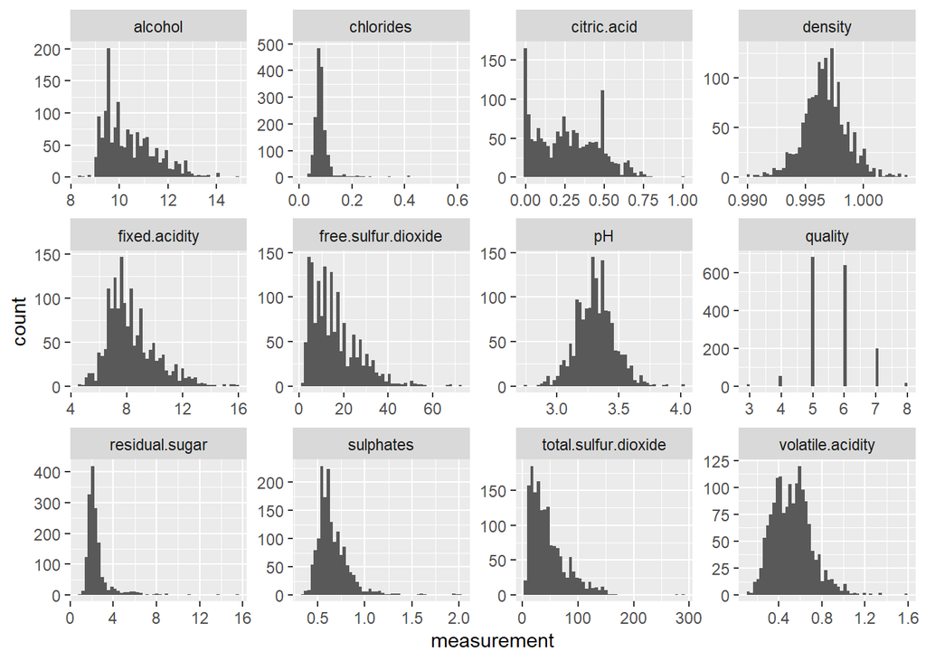

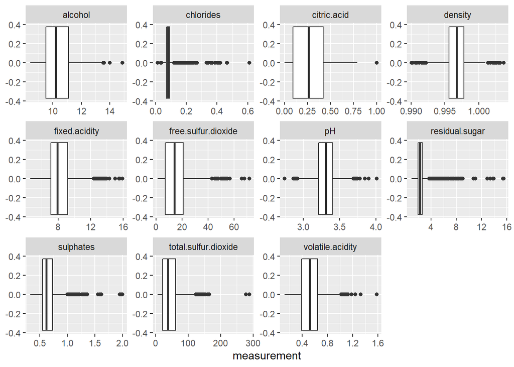

At a first glance, pH, density and quality have symmetric, normal-like distributions. The other variables are right skewed.

Plotting the histograms again with a logarithmic scale provides a better view on extreme values:

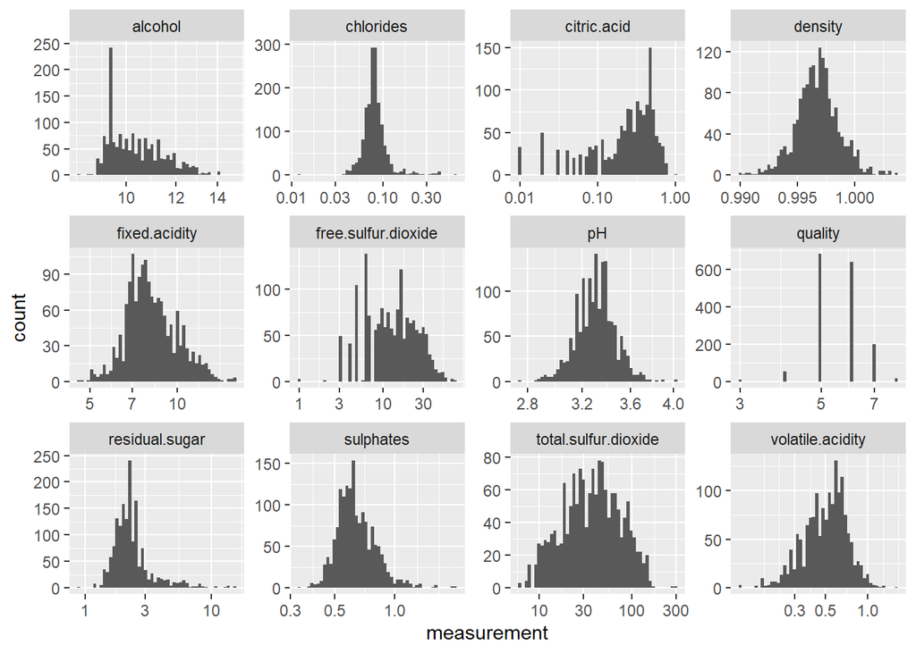

In order to better visualize the variables with long-tailed distributions, I create a filtered dataset (with manually set limits per variable) and plot the histograms again:

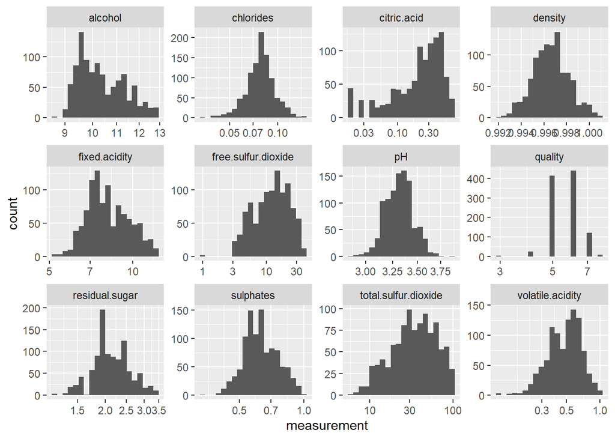

Looking at quality:

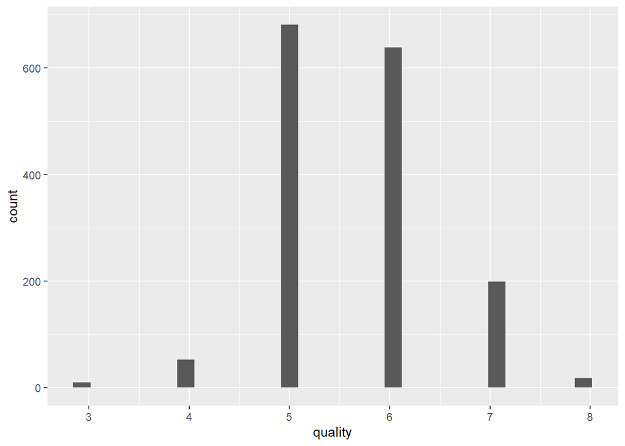

```
##
##   3   4   5   6   7   8
##  10  53 681 638 199  18
```

```
##    Min. 1st Qu.  Median    Mean 3rd Qu.    Max.
##   3.000   5.000   6.000   5.636   6.000   8.000
```

Quality can take values form 0 to 10. The wines present in the dataset only span a range from 3 to 8. There are no *very good* or *very bad* wines; the majority has a quality of 5 or 6.

Introducing a new categorical variable, reducing quality to three grades:

```
##
##    bad medium   good
##     63   1319    217
```

There are only very few bad wines.

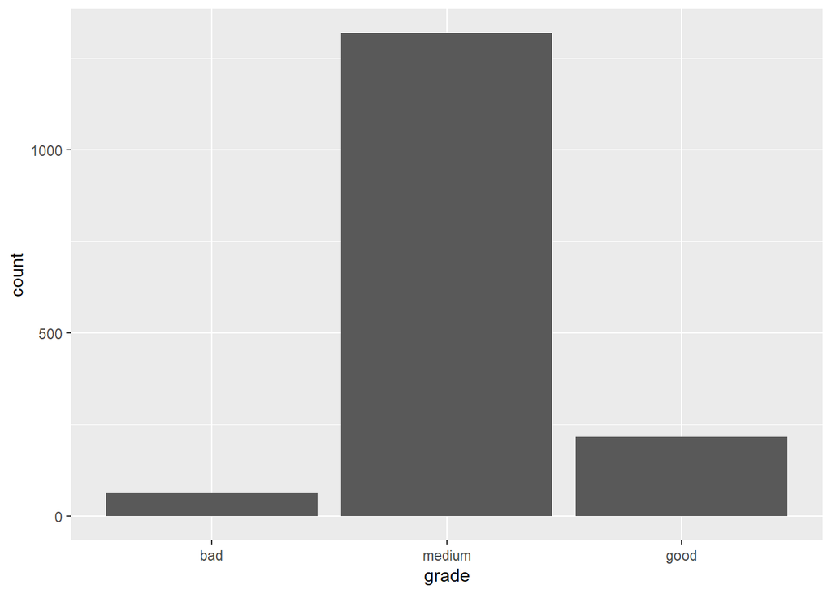

Quality is distributed very unevenly - the majority of wines is in the “medium” group, and there are only very few bad wines.

# Univariate Analysis

Summary statistics of data:

```
##  fixed.acidity   volatile.acidity  citric.acid    residual.sugar
##  Min.   : 4.60   Min.   :0.1200   Min.   :0.000   Min.   : 0.900
##  1st Qu.: 7.10   1st Qu.:0.3900   1st Qu.:0.090   1st Qu.: 1.900
##  Median : 7.90   Median :0.5200   Median :0.260   Median : 2.200
##  Mean   : 8.32   Mean   :0.5278   Mean   :0.271   Mean   : 2.539
##  3rd Qu.: 9.20   3rd Qu.:0.6400   3rd Qu.:0.420   3rd Qu.: 2.600
##  Max.   :15.90   Max.   :1.5800   Max.   :1.000   Max.   :15.500
##    chlorides       free.sulfur.dioxide total.sulfur.dioxide    density
##  Min.   :0.01200   Min.   : 1.00       Min.   :  6.00       Min.   :0.9901
##  1st Qu.:0.07000   1st Qu.: 7.00       1st Qu.: 22.00       1st Qu.:0.9956
##  Median :0.07900   Median :14.00       Median : 38.00       Median :0.9968
##  Mean   :0.08747   Mean   :15.87       Mean   : 46.47       Mean   :0.9967
##  3rd Qu.:0.09000   3rd Qu.:21.00       3rd Qu.: 62.00       3rd Qu.:0.9978
##  Max.   :0.61100   Max.   :72.00       Max.   :289.00       Max.   :1.0037
##        pH          sulphates         alcohol         quality         grade
##  Min.   :2.740   Min.   :0.3300   Min.   : 8.40   Min.   :3.000   bad   :  63
##  1st Qu.:3.210   1st Qu.:0.5500   1st Qu.: 9.50   1st Qu.:5.000   medium:1319
##  Median :3.310   Median :0.6200   Median :10.20   Median :6.000   good  : 217
##  Mean   :3.311   Mean   :0.6581   Mean   :10.42   Mean   :5.636
##  3rd Qu.:3.400   3rd Qu.:0.7300   3rd Qu.:11.10   3rd Qu.:6.000
##  Max.   :4.010   Max.   :2.0000   Max.   :14.90   Max.   :8.000
```

### What is the structure of your dataset?

```
## [1] 1599   14
```

The dataset has 12 variables and 1599 observations. All variables except quality are real numbers. Quality is an integer variable. There are no missing values. There are no obviously incorrect values (like negative values.)

### What is/are the main feature(s) of interest in your dataset?

The wine quality is the main feature of interest. As suggested in the datasets documentation, it was created the purpose of developing regression models that can predict the wine quality from physical & chemical measurement results.

### What other features in the dataset do you think will help support your investigation into your feature(s) of interest?

To me, the most interesting question is which variables have the strongest influence on wine quality. Potentially, all variables may have an influence.

### Did you create any new variables from existing variables in the dataset?

I created a categorical variable ‘grade’ from quality.

### Of the features you investigated, were there any unusual distributions? Did you perform any operations on the data to tidy, adjust, or change the form of the data? If so, why did you do this?

Alcohol and citric acid content have highly asymmetrical, almost triangular distributions.

Quality has a bell-shaped distribution, there are few good ones and even fewer bad ones.

# Bivariate Plots Section

A pair plot (scatterplot matrix) provides a first overview of dependencies and potential correlations between variables:

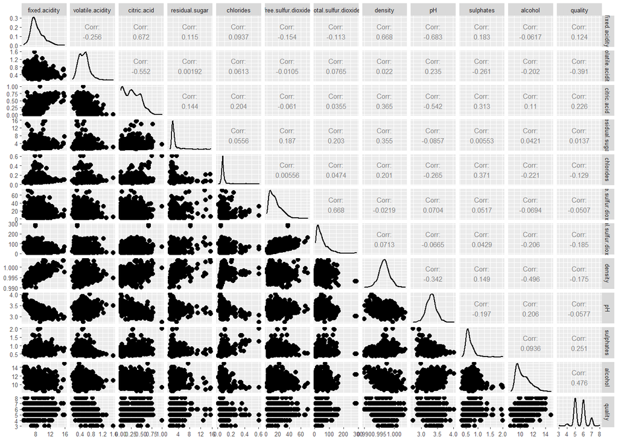

Again a pair plot, this time using the categorical quality value:

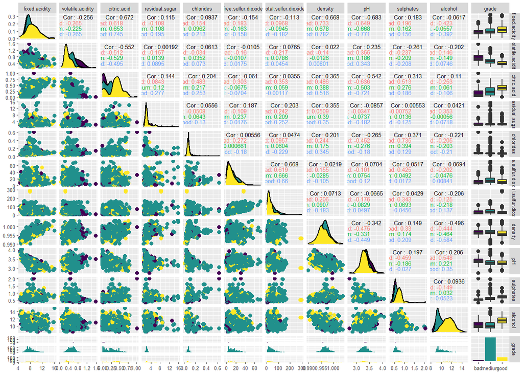

For the main variable of interest (quality), the highest correlations are with volatile acidity, alcohol, and sulphates.

High values of correlation also occur in these groups:

- volatile acidity, fixed.acidity, citric acid, density, pH
- density, alcohol, pH, fixed.acidity, citric.acid, residual.sugar

### Which variables influence quality?

The following plots highlight patterns between the measured variables and the wine quality:

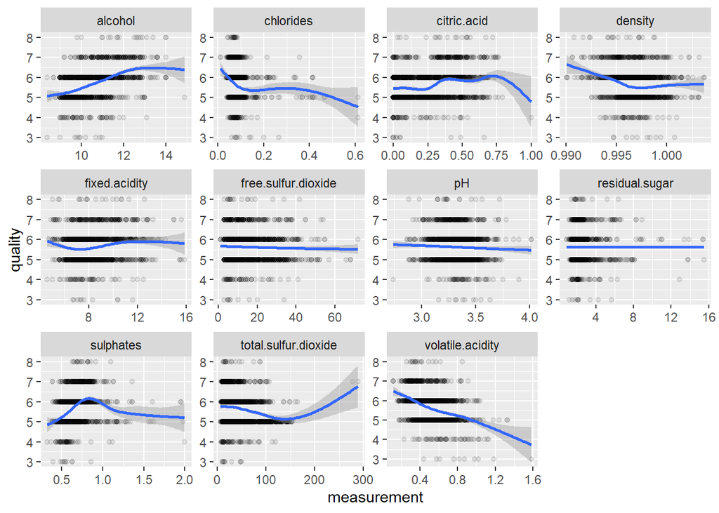

- alcohol, density, total.sulfur.dioxide, volatile acidity
- free sulfur dioxide and residual sugar do not have an influence.
- nonlinear relationships (which are not captured by linear correlation measures or linear models): citric acid, chlorides, sulphates

### Which variables influence the pH value?

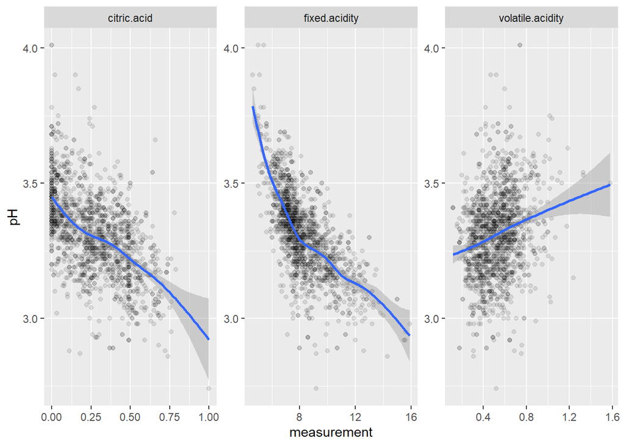

correlation between pH and fixed.acidity:

```
## [1] -0.6829782
```

correlation between pH and volatile acidity:

```
## [1] 0.2349373
```

correlation between pH and citric acid:

```
## [1] -0.5419041
```

Conclusion:

- medium correlation between pH and citric.acid and fixed.acidity
- no clear correlation between pH and volatile.acidity

# Bivariate Analysis

### Talk about some of the relationships you observed in this part of the investigation. How did the feature(s) of interest vary with other features in the dataset?

The alcohol content has the strongest influence on wine quality. The variables with the next highest correlation coefficients are sulphates and volatile acidity.

### Did you observe any interesting relationships between the other features (not the main feature(s) of interest)?

Relationships exist

### What was the strongest relationship you found?

# Multivariate Plots Section

### Explore relationship between quality, alcohol, volatile acidity, sulphates

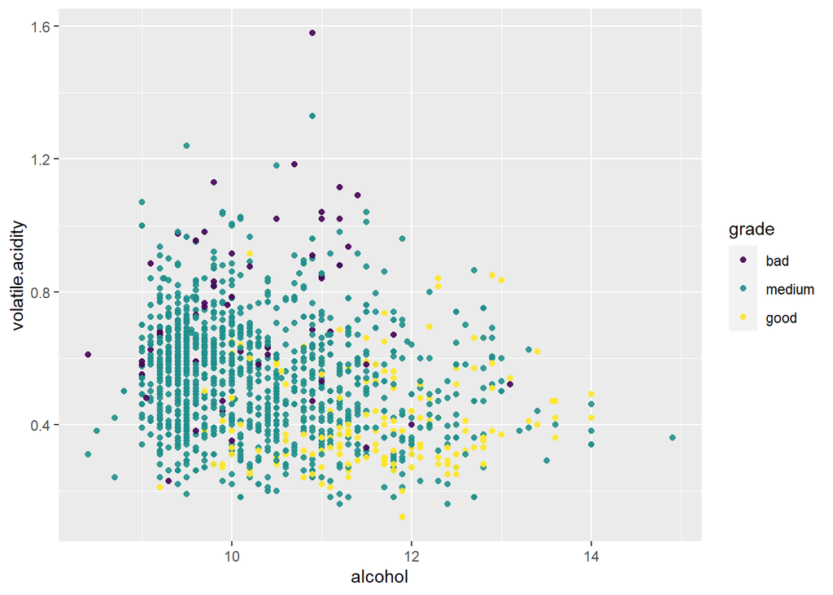

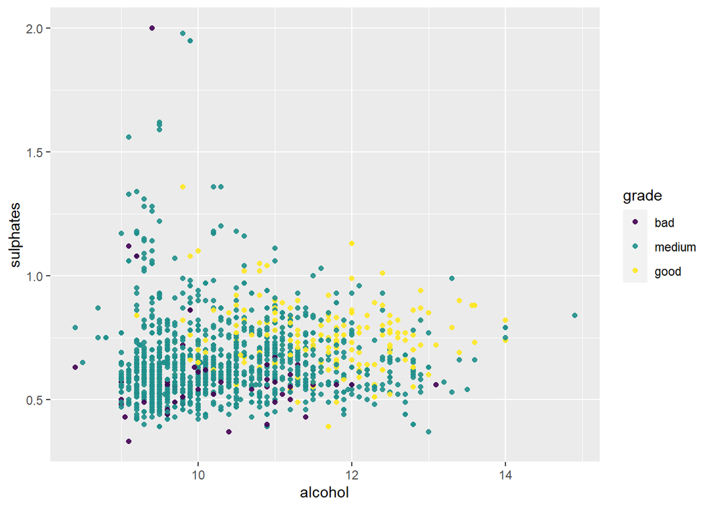

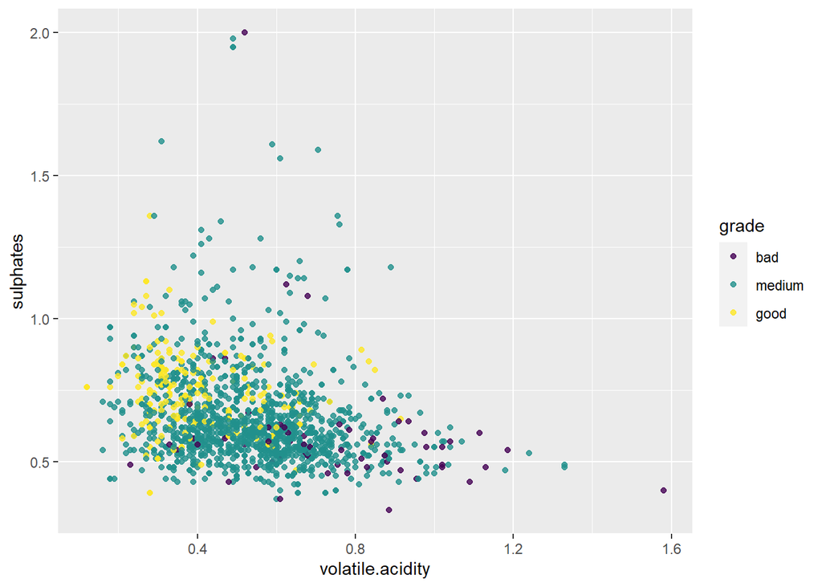

In the plots above, bad and good wines are separated - if there were just good ones and bad ones, the three variables could be used to classify wines. However, the majority of wines are in the medium group, and they cover the whole range of values, making a classification (with the given variables and linear decision boundaries) difficult.

# Multivariate Analysis

### Talk about some of the relationships you observed in this part of the investigation. Were there features that strengthened each other in terms of looking at your feature(s) of interest?

In the plots above, bad and good wines are separated - if there were just good ones and bad ones, the three variables could be used to classify wines. However, the majority of wines are in the medium group, and they cover the whole range of values, making a classification (with the given variables and linear decision boundaries) difficult.

# Final Plots and Summary

### Plot One

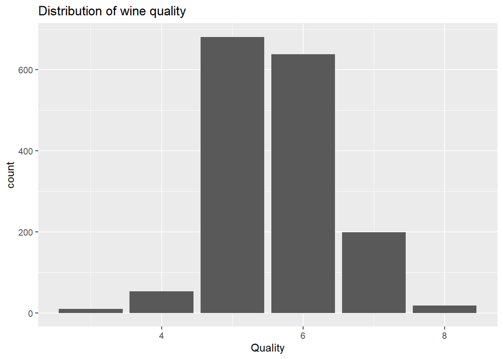

### Description One

On a possible range from 0 to 10, all wines fall between 3 and 8, and the majority has quality ratings of 5 or 6.

### Plot Two

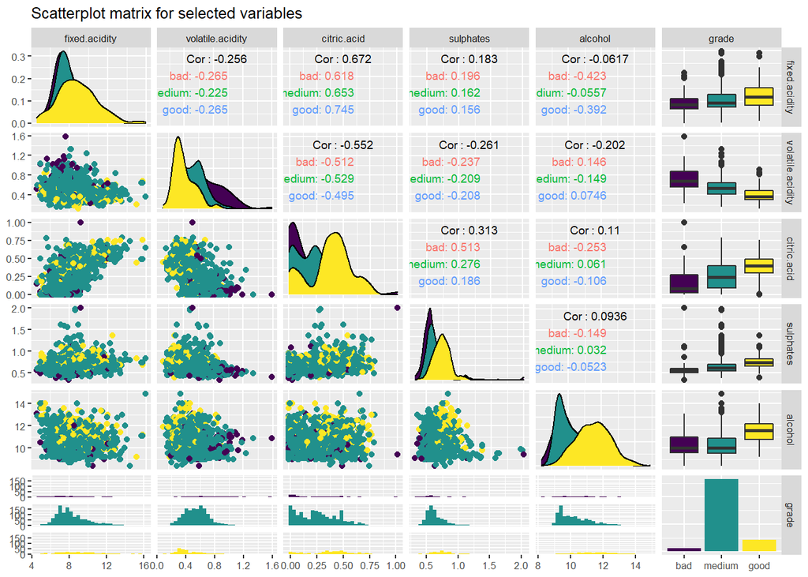

### Description Two

The scatterplot matrix shows those variable where distributions differ among  
wine “grades”. This subset of variables could be a starting point for building classification or regression models.

### Plot Three

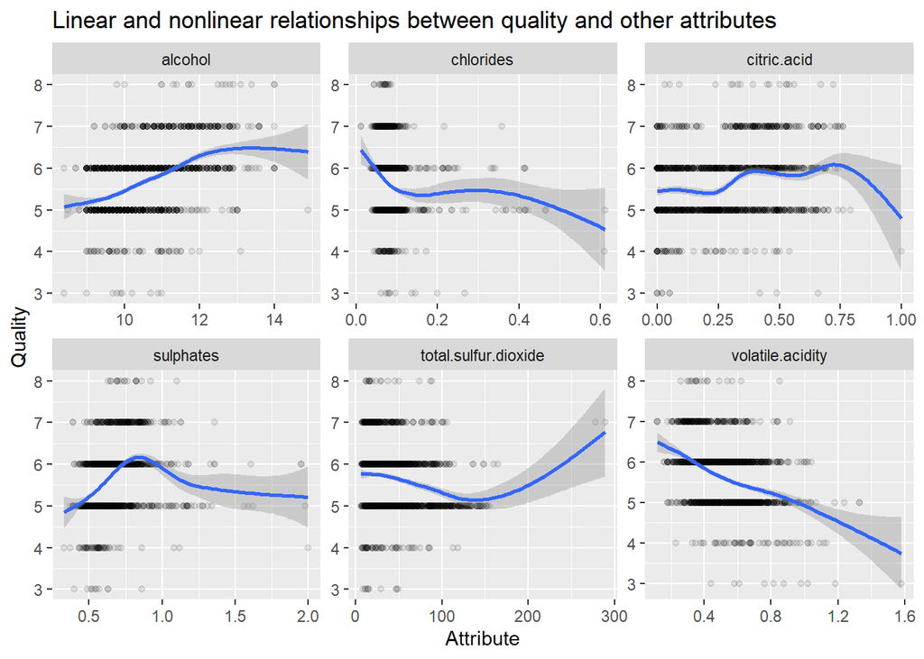

### Description Three

This plot shows that there are nonlinear relationships between quality and some of the other variables, e.g. citric acid. A good classification or regression model would have to capture these nonlinear relationships.

# Reflection

The dataset can be used to predict the wine quality from physical/chemical measurements.

Difficulties with this dataset:

- the majority of data lies in the medium range; there are relatively few ‘good’ or ‘bad’ examples. There are no samples for extreme cases (quality below three or above 8).
- There are nonlinear relationships between some variables (e.g. citric acid and quality). Linear correlation measures do not capture these.

Successes:

- Alcohol content is a good indicator for wine quality
- There are some correlations between the variables (e.g. fixed acidity and pH). These could be used to eliminate some of the variables and reduce the number of dimensions of the problem.

Enriching the analysis:

- More data for extreme cases (good / bad wines)
- use nonlinear models
- use dimensionality reduction